# R Notebook

Dhruv Dole, Ahmed Gharib

# Is there a relationship between students’ socioeconomic status and there academic test scores?

```r
library(tidyverse)
raw_data <- read.csv("https://raw.githubusercontent.com/dsdole/DS202Final/main/data/Expanded_data_with_more_features.csv")
```

# Erasing “X” from the dataset:

```r
raw_data <- select(raw_data, -X)
```

```r
raw_data$Gender <- as.factor(raw_data$Gender)
raw_data$EthnicGroup <- as.factor(raw_data$EthnicGroup)
raw_data$ParentEduc <- as.factor(raw_data$EthnicGroup)
raw_data$LunchType <- as.factor(raw_data$LunchType)
raw_data$TestPrep <- as.factor(raw_data$TestPrep)
raw_data$ParentMaritalStatus <- as.factor(raw_data$ParentMaritalStatus)
raw_data$TransportMeans <- as.factor(raw_data$TransportMeans)

#raw_data$isFirstChild <- as.factor(raw_data$isFirstChild)
```

# Factoring WklyStudyHours

```r
unique(raw_data$WklyStudyHours)
```

```
## [1] "< 5"    "5 - 10" "> 10"   ""
```

```r
raw_data$WklyStudyHours <- factor(raw_data$WklyStudyHours, ordered = TRUE,
                                  levels = c("< 5", "5 - 10", "> 10"))
```

# Filling empty space

```r
cleanraw_data <- raw_data %>%
  mutate_all(~replace(., . == "", NA))
cleanraw_data %>%
  summarise_all(~mean(is.na(.)) * 100)
```

```
##   Gender EthnicGroup ParentEduc LunchType TestPrep ParentMaritalStatus
## 1      0    6.005026   6.005026         0  5.97239            3.883685
##   PracticeSport IsFirstChild NrSiblings TransportMeans WklyStudyHours MathScore
## 1      2.059332     2.950295   5.130381       10.22813       3.116739         0
##   ReadingScore WritingScore
## 1            0            0
```

# Visual of clean data

```r
head(cleanraw_data)
```

```
##   Gender EthnicGroup ParentEduc    LunchType TestPrep ParentMaritalStatus
## 1 female        <NA>       <NA>     standard     none             married
## 2 female     group C    group C     standard     <NA>             married
## 3 female     group B    group B     standard     none              single
## 4   male     group A    group A free/reduced     none             married
## 5   male     group C    group C     standard     none             married
## 6 female     group B    group B     standard     none             married
##   PracticeSport IsFirstChild NrSiblings TransportMeans WklyStudyHours MathScore
## 1     regularly          yes          3     school_bus            < 5        71
## 2     sometimes          yes          0           <NA>         5 - 10        69
## 3     sometimes          yes          4     school_bus            < 5        87
## 4         never           no          1           <NA>         5 - 10        45
## 5     sometimes          yes          0     school_bus         5 - 10        76
## 6     regularly          yes          1     school_bus         5 - 10        73
##   ReadingScore WritingScore
## 1           71           74
## 2           90           88
## 3           93           91
## 4           56           42
## 5           78           75
## 6           84           79
```

# Initial Assumptions:

We believe that there is a significant relationship between socioeconomic status and student test scores. Namely, We expect variables such as WklyStudyHours, ParentMaritalStatus, LunchType, and ParentEduc to all have a relationship with The three score variables.

# Analysis:

## 1(Ahmed) - Average score affected by students according to their Practicing sports status:

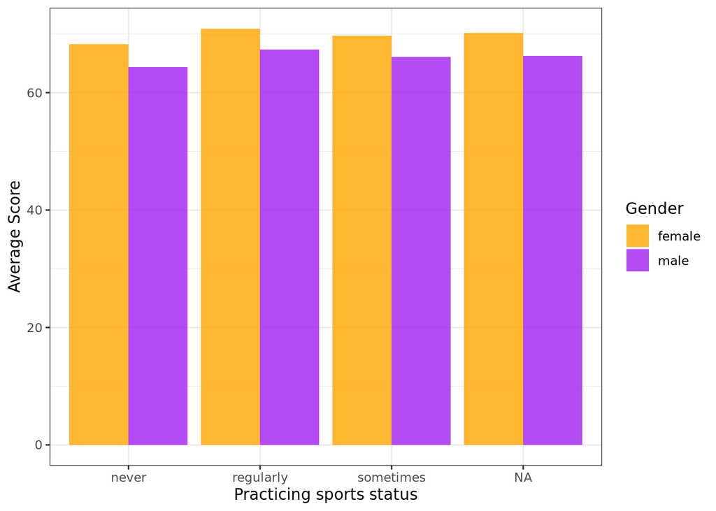

```r
# library(ggplot2)

AvgScore <- rowMeans(cleanraw_data[, c("MathScore", "ReadingScore", "WritingScore")], na.rm = TRUE)


ggplot(cleanraw_data, aes(x = PracticeSport, y = AvgScore, fill = Gender)) +
  stat_summary(fun = mean, geom = "bar", position = "dodge", alpha = 0.8) +
  scale_fill_manual(values = c("orange", "purple")) +
  labs(x = "Practicing sports status", y = "Average Score", fill = "Gender") +
  theme_bw()
```

As we can see above the Average overall scores affected by students who practice sports compared to those who do not, is not a huge difference. Very similar overall.

## 2(Ahmed) - Weekly study hours affection of Average scores

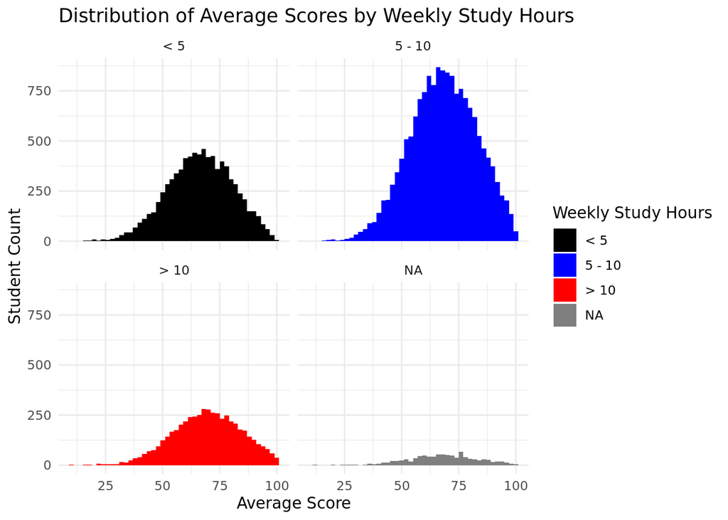

```r
# Load required packages
# library(ggplot2)

# Compute average score
AvgScore <- rowMeans(cleanraw_data[, c("MathScore", "ReadingScore", "WritingScore")], na.rm = TRUE)

ggplot(cleanraw_data, aes(x = AvgScore, fill = factor(WklyStudyHours))) +
  geom_histogram(binwidth = 2, position = "dodge") +
  scale_fill_manual(values = c("black", "blue", "red")) +
  facet_wrap(~WklyStudyHours) + # remove this line to remove facets
  labs(title = "Distribution of Average Scores by Weekly Study Hours",
       x = "Average Score",
       y = "Student Count",
       fill = "Weekly Study Hours") +
  theme_minimal()
```

For the above histogram, gathering the distribution of weekly hours of study seeing how that affects the overall scores of the students. As seen students that study less than 5 hours a week, have a peak range around 60-75. Similarly, students who study for more than 10 hours, have around the same range peak. But less students. Seems like 5-10 hours of study weekly is the best amount of hours in order to get better scores for the more students in this data set.

## 3(Ahmed) - Correlating Number of siblings to each individual scores (Lineplot)

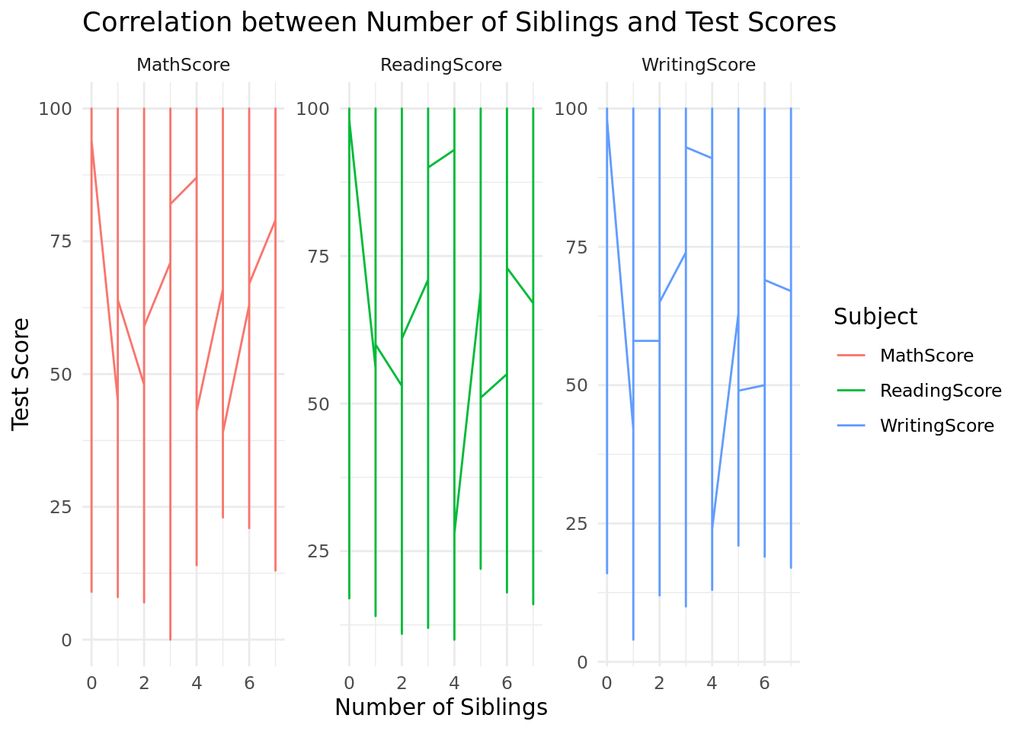

```r
# library(tidyr)

# Create a new data frame with columns for NbrSiblings, MathScore, ReadingScore, and WritingScore
scores_by_siblings <- cleanraw_data %>%
  select(NrSiblings, MathScore, ReadingScore, WritingScore) %>%
  na.omit()

# Reshape the data to long format
scores_by_siblings_long <- scores_by_siblings %>%
  pivot_longer(cols = c("MathScore", "ReadingScore", "WritingScore"), names_to = "Subject", values_to = "Score")

# Create a line plot with facets for each subject
ggplot(scores_by_siblings_long, aes(x = NrSiblings, y = Score, group = Subject)) +
  geom_line(aes(color = Subject)) +
  labs(title = "Correlation between Number of Siblings and Test Scores",
       x = "Number of Siblings",
       y = "Test Score",
       color = "Subject") +
  facet_wrap(~Subject, scales = "free_y") +
  theme_minimal()
```

## 4(Dhruv) - Mosiac Plot between Ethnic Group and Parent Marital Status

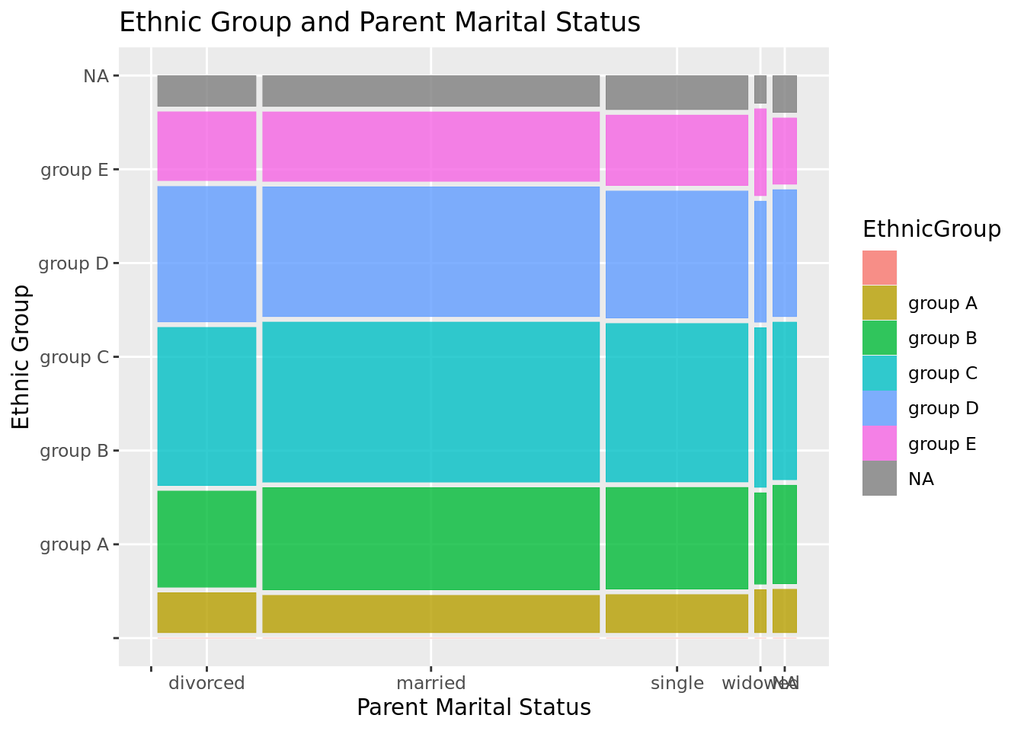

```r
library(ggmosaic)
mosaic_examp <- ggplot(data = cleanraw_data) +
  geom_mosaic(aes(x = product(EthnicGroup, ParentMaritalStatus), fill = EthnicGroup)) +
  labs(y = "Ethnic Group", x = "Parent Marital Status", title = "Ethnic Group and Parent Marital Status")
mosaic_examp
```

There is no relation between Ethnic Group and Parent Marital Status. This is because there is no change in the proportions from column to column or row to row. This means that we can use these as independent predictors for model building.

## 5(Dhruv) - Scatter plot of MathScore vs ReadingScore, Grouped by EthnicGroup and Gender

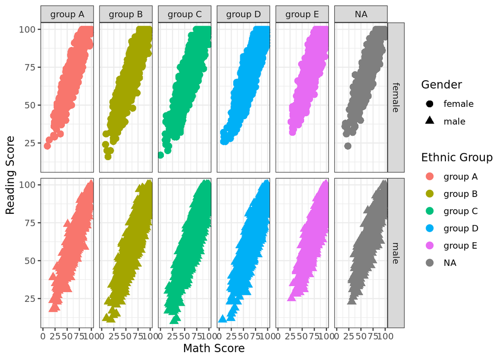

```r
ggplot(cleanraw_data, aes(x = MathScore, y = ReadingScore, color = EthnicGroup, shape = Gender)) +
  geom_point(size = 3) +
  facet_grid(Gender ~ EthnicGroup) +
  labs(x = "Math Score", y = "Reading Score", color = "Ethnic Group", shape = "Gender") +
  theme_bw()
```

The above plot shows a distribution of scores which is highly consistent among all ethnic groups. That being said, groups A, B, and C show some lower outliers for female student. Males students have some lower outliers in groups B, C, and D.

## 6(Dhruv) - Stacked Boxplot of Math Scores

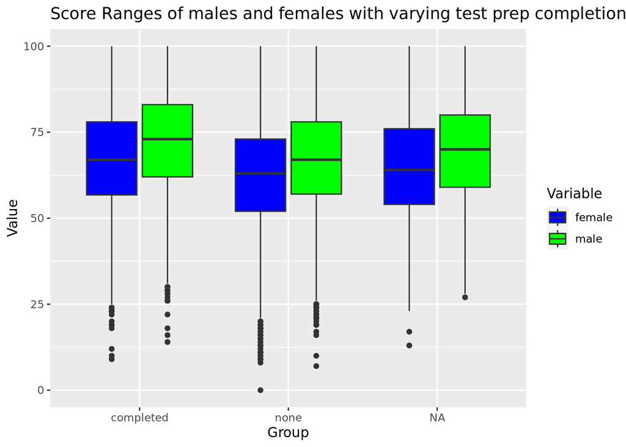

```r
ggplot(cleanraw_data, aes(x = TestPrep, y = MathScore, fill = Gender)) +
  geom_boxplot() +
  scale_fill_manual(values = c("blue", "green", "red")) +
  labs(x = "Group", y = "Value", fill = "Variable") +
  ggtitle("Score Ranges of males and females with varying test prep completion")
```

The boxplots show that each group has nearly equivalent ranges, however those students which complete their test prep are shown to have a higher mean score. There are many outliers along the lower end of all the ranges, this is due to the fact that while most tests are graded 0-100, the average or “C” grade is usually in the 70’s. This leaves a significant portion of the range below the mean.